# SS21 STT 180 Homework 3

# Section 2

For this section of this homework will use the`abalone.csv` file from UCI repository (https://archive.ics.uci.edu/ml/datasets/Abalone).

The number of rings in the shell of a abalone is indicative of its age. This is done by cutting the shell through the cone, staining it, and counting the number of rings through a microscope – a boring and time-consuming task. In this section, we will analyze the relationship between age (measured by the number of rings) and a few different variables present in the data.

```r
ab <- read.csv("abalone.csv")
glimpse(ab)
```

```
Rows: 4,177
Columns: 11
$ Sex      <chr> "M", "M", "F", "M", "I", "I", "F", "F", "M", "F", "F", "M", "…
$ Length   <dbl> 0.455, 0.350, 0.530, 0.440, 0.330, 0.425, 0.530, 0.545, 0.475…
$ Diameter <dbl> 0.365, 0.265, 0.420, 0.365, 0.255, 0.300, 0.415, 0.425, 0.370…
$ Height   <dbl> 0.095, 0.090, 0.135, 0.125, 0.080, 0.095, 0.150, 0.125, 0.125…
$ Whole    <dbl> 0.5140, 0.2255, 0.6770, 0.5160, 0.2050, 0.3515, 0.7775, 0.768…
$ Shucked  <dbl> 0.2245, 0.0995, 0.2565, 0.2155, 0.0895, 0.1410, 0.2370, 0.294…
$ Viscera  <dbl> 0.1010, 0.0485, 0.1415, 0.1140, 0.0395, 0.0775, 0.1415, 0.149…
$ Shell    <dbl> 0.150, 0.070, 0.210, 0.155, 0.055, 0.120, 0.330, 0.260, 0.165…
$ Rings    <int> 15, 7, 9, 10, 7, 8, 20, 16, 9, 19, 14, 10, 11, 10, 10, 12, 7,…
$ X        <lgl> NA, NA, NA, NA, NA, NA, NA, NA, NA, NA, NA, NA, NA, NA, NA, N…
$ X.1      <lgl> NA, NA, NA, NA, NA, NA, NA, NA, NA, NA, NA, NA, NA, NA, NA, N…
```

### Question 1

We will start by analyzing a simple bivariate relationship between age and height.

Plot a scatter plot to get an idea about the relationship between height and age. Comment (1-3 sentences) on the plot.

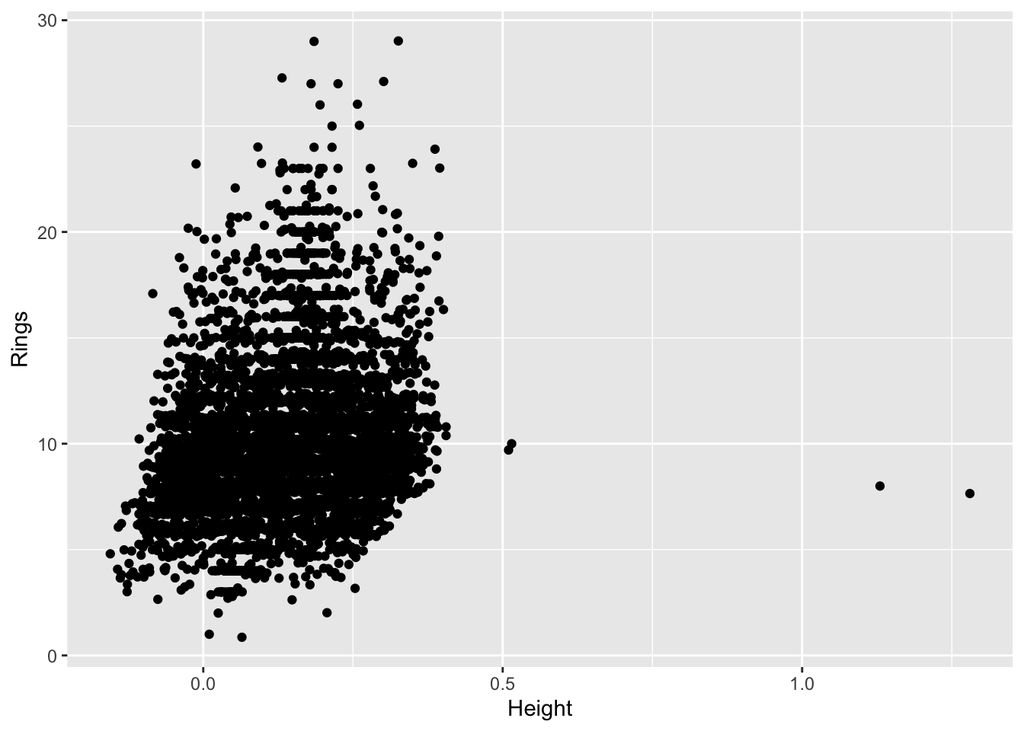

```r
ggplot(ab, aes(x = Height, y =Rings)) + geom_jitter(position = position_jitter(width = 0.2)) +
    geom_point()
```

```r
# The scatter shows a trend of as the age reaches in between 5-15 range, the height begins to round out/stagnate in between 0.1 through 0.4.
```

### Question 2

Modify the plot in Question 1 to reflect the effect of the variable `Sex` in the plot.

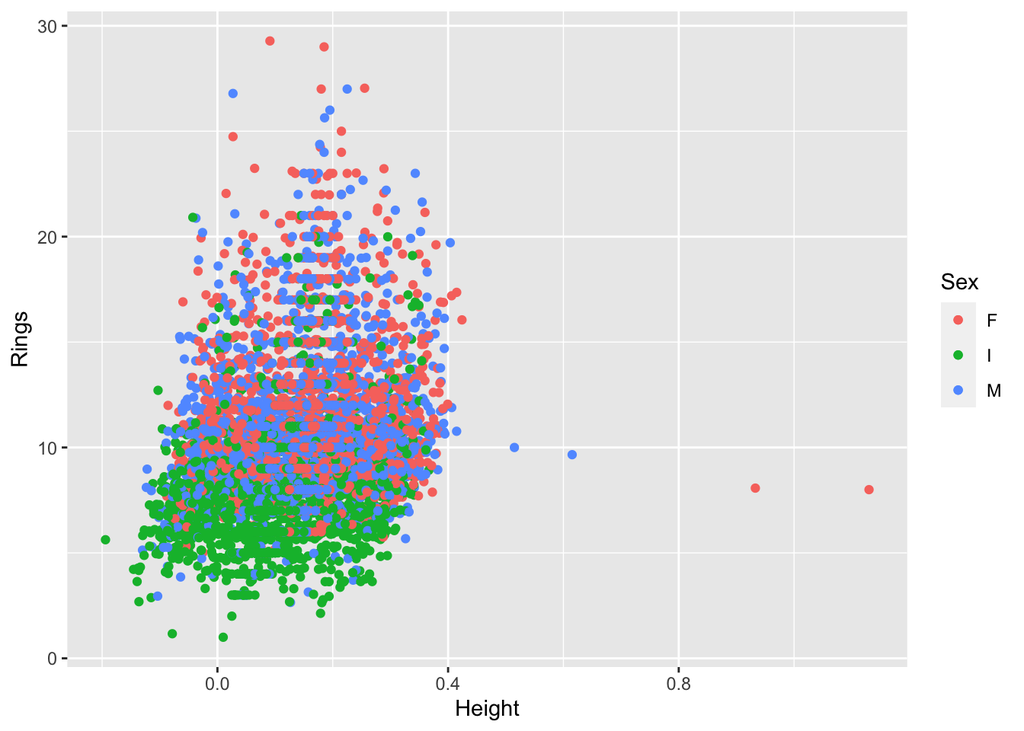

```r
ggplot(ab, aes(x = Height, y =Rings, colour =Sex)) + geom_jitter(position = position_jitter(width = 0.2)) +
    geom_point()
```